# Распределение интервалов между транзакциями

Vladimir Silkin

20 08 2021

## Распределение интервалов между транзакциями

Известно, что интервалы между сообщениями в онлайн-чате подчиняются степенному распределению, [как утверждали ученые из Цюриха и Вены в 2012 году](https://www.nature.com/articles/srep00402), а интервалы между двумя последовательными покупателями или двумя последовательными звонками в колл-центре при определенных допущениях могут подчиняться экспоненциальному распределению, как [утверждает википедия](https://en.wikipedia.org/wiki/Exponential_distribution#Occurrence_and_applications).

А вот автор [статьи на Хабре про типичные распределения вероятностей](https://habr.com/ru/post/331060/) сказал бы, что глупо постулировать принадлежность чего-то определенному распределению, потому что разные сущности могут вести себя по-разному при соответствующих допущениях. Экспоненциальное распределение, например, лишь частный случай более общего распределения Вейбулла, которое позволяет моделировать увеличивающуюся (или уменьшающуюся) со временем интенсивность событий (поступления звонков или прихода покупателей). Таким образом, экспоненциальное распределение покупателей в магазине - абстракция, которая лишь в общих чертах описывает реальность. Посмотрите, например, [историю с автобусами на Хабре](https://habr.com/ru/post/428610/).

Вернемся к примеру с распределением интервалов между сообениями в онлайн-чате. Результаты указанной статьи лучше посмотреть в [интерпретации журнала Physics Today](https://physicstoday.scitation.org/doi/full/10.1063/PT.3.3845). Очевидно, что процесс отправки сообщений нельзя считать процессом без памяти, потому что каждое новое сообщение не является независимым, как и в случае с приходом автобусов, интервалы между которыми в реальности характеризуются определенной равномерностью.

Я решил сделать ресёрч интервалов между собственными банковскими тратами за последние полгода и понять, какому распределению эти интервалы будут подчиняться. Ожидается, что процесс совершения оплаты в большей степени должен быть похож на процесс отправки сообщений, чем на процесс поступления звонков или прихода покупателей прежде всего потому, что исходит от первого лица.

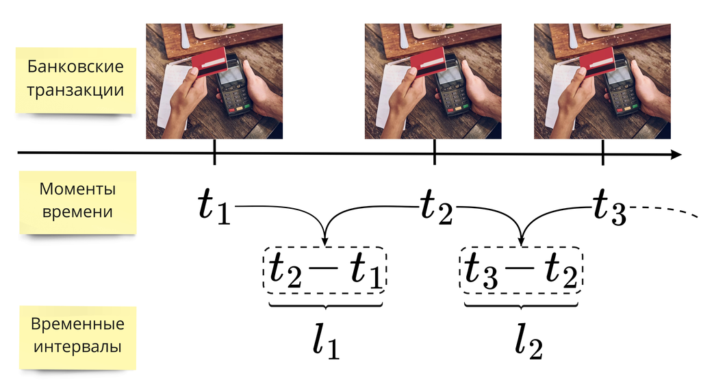

В статье я представляю:

1. Код на R для анализа любых временных интервалов.
2. Подбор экспоненциального и степенного распределения под данные с помощью метода максимального правдоподобия (MLE). Для экспоненциального я использую `fitdistr()` из пакета `MASS`, а для степенного `fit_power_law()` из пакета `igraph`.
3. Проверку данных на соответствие подобранному распределению с помощью теста Колмогорова-Смирнова. Я использую функцию `ks.test` из пакета `stats`.

В конце статьи я оставляю ряд открытых вопросов и буду рад, если в комментарии придет эксперт по подбору распределений под данные и сможет их прояснить.

### Выгрузка данных.

Для начала стоит выгрузить данные из банковского приложения. Как это сделать в Тинькоф или Рокетбанк, можно подсмотреть в [статье на Хабре про статистику расходов по МСС](https://habr.com/ru/post/414349/). Меня интересуют только интервалы размером менее суток, потому что для анализа интервалов продолжительностью более суток моих данных маловато, потому что я не слишком часто сидел в спецприемниках и ходил в горы. Файл с интервалами доступен [по ссылке](https://drive.google.com/file/d/155ACYB48Wamj203INVF8YB4Zq6YkukjH/view?usp=sharing).

### Смотрим на данные глобально

После выгрузки данных посчитаем основные описательные статистики – медиану и среднее и построим базовые графики - плотность, гистограмму и боксплот.

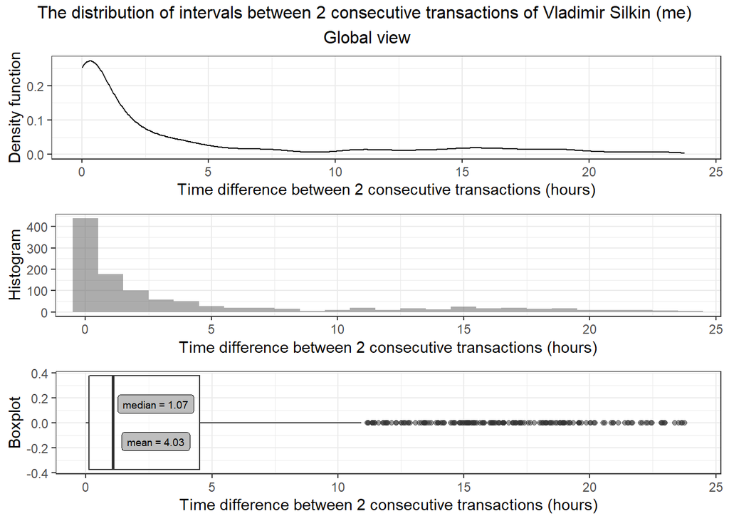

Как видно из построенной визуализации, все данные можно поделить на 2 группы – примерно от 0 до 8 часов и от 8 до 24.

- Распределение **первых** похоже на экспоненциальное или степенное. Состоит из небольших промежутков между тратами и может быть связано с распределением трат внутри определенных патернов действий (сходить на прогулку и в разных местах много чего купить). Это мое оценочное суждение.
- Распределение **вторых** похоже на нормальное. Состоит из промежутков между тратами около среднего времени бодрстовавания - 16 часов.

Можно ли объяснить данные указанными распределениями, узнаем чуть позже. Давайте сперва взглянем на них поглубже.

### Берем фокус на двух частях распределения.

Экспоненциальное/степенное, которое связано небольшими промежутками трат. Обозначено на следующем графике **красным цветом**. Околонормальное распределение данных возле среднего промежутка бодрстовавания - 16 часов. Обозначено **синим цветом**.

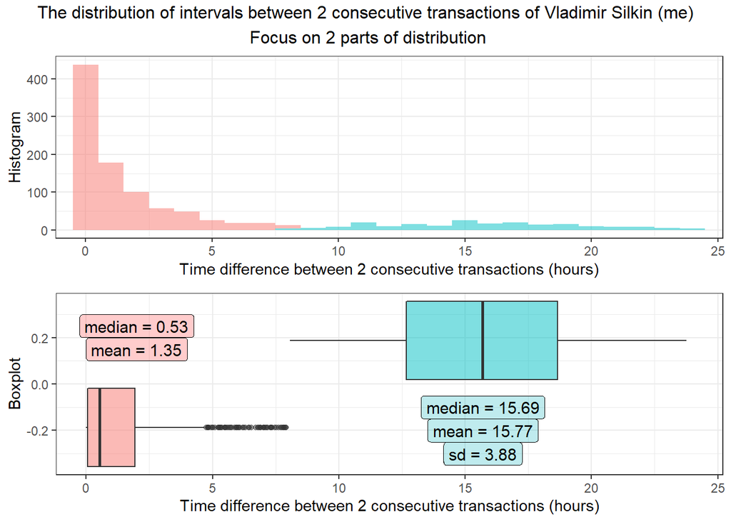

#### 1. Проверка на нормальность

Сперва разберемся с нормальным распределением. Насколько оно нормально?

```r
shapiro.test(tr_buy[intervals > 8, intervals])
```

```
##
##  Shapiro-Wilk normality test
##
## data:  tr_buy[intervals > 8, intervals]
## W = 0.98146, p-value = 0.008602
```

На следующем графике сплошная линия показывает функцию плотности наших данных, а пунктирная – функцию плотности идеального нормального распределения.

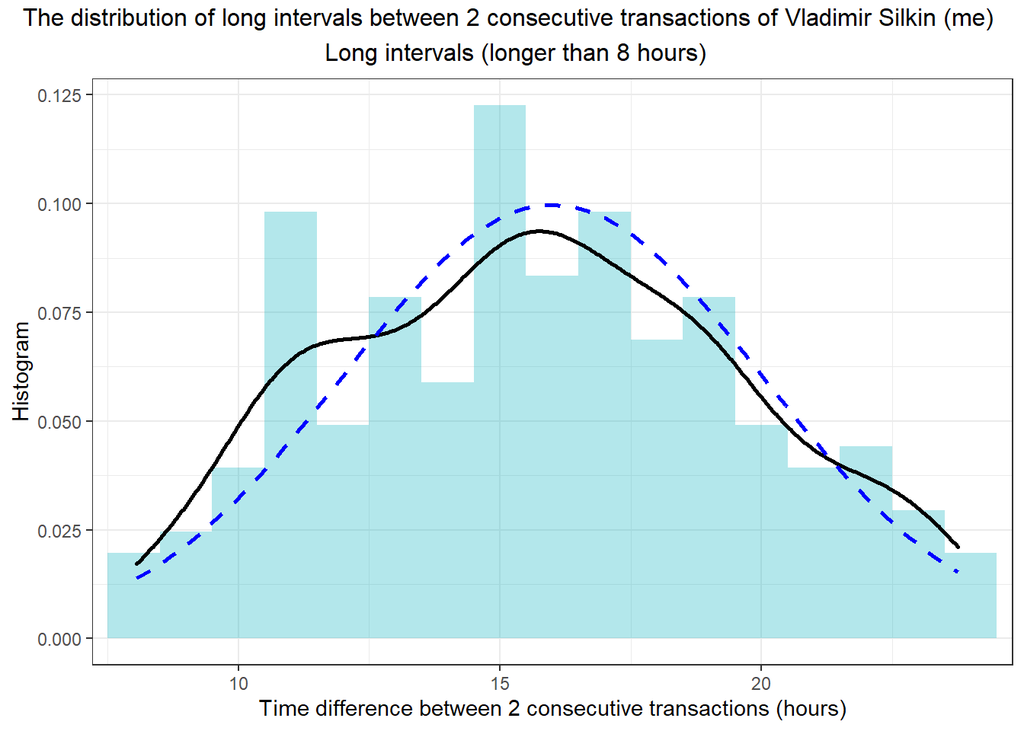

#### 2. Подбор экспоненциального и степенного распределений

Теперь попробуем фитануть плотность вероятности с помощью двух распределений - экспоненциального и степенного. Они перед вами.

$$\begin{gather}
f_{exp}(x) = \alpha \, e^{-\alpha \, x} \\
f_{pow}(x) = x^{-\alpha}
\end{gather}$$

> В работе Data-Scientist`а нет ничего сложного. Главное – подгрузить нужные библиотеки. ([Маэстро](https://stepik.org/lesson/216065/step/4?unit=188927))

```r
library(MASS) # Для подбора экспоненциального распределения с помощью fitdistr()
library(igraph) # Для подбора степенного распределения с помощью fit_power_law()
library(stats) # Для проведения теста Колмогорова-Смирнова
```

**Фитуем данные экспоненциальным распределением:**

```r
fit_e <- fitdistr(tr_buy[intervals < 8, intervals], "exponential")
fit_e$estimate[1][[1]] # alpha
fit_e$sd[1][[1]] # alpha_error
ks.test(tr_buy[intervals < 8, intervals], "pexp", fit_e$estimate)$p.value #p.value
```

Получим $\alpha \approx 0.74$ и $p.value \approx 0$. Первое найдено с помощью метода максимального правдоподобия, а второе – с помощью теста Колмогорова-Смирнова.

Физический смысл результатов теста состоит в следующем: если в генеральной совокупности данные, действительно, распределены экспоненциально, то вероятность получить такие и сколь угодно выраженные отклонения от экспоненциального распределения случайно, практически равна нулю. То есть в p.value находится вероятность получить нашу выборку и любую другую выборку, хоть сколько-нибудь отличающуюся от идеальной выборки экспоненциальных данных сильнее нашей.

**Фитуем данные степенным распределением:**

```r
fit_p <- fit_power_law(tr_buy[intervals < 8, intervals], implementation = 'plfit')
fit_p$alpha # alpha
fit_p$KS.p  # p-уровень значимости из теста Колмогорова-Смирнова
```

Получим $\alpha \approx 2.17$ и $p.value \approx 10^{-5}$.

В случае со степенным распределеним p.value повышается, но все равно не достигает ни одного общепринятого порога значимости.

**Итоги:**

| Equation | Parameter | Significance |
| --- | --- | --- |
| $f_{exp}(x) = \alpha \, e^{-\alpha \, x}$ | $\alpha \approx 0.74$ | $p.value < 10^{-16}$ |
| $f_{pow}(x) = x^{-\alpha}$ | $\alpha \approx 2.17$ | $p.value \approx 10^{-5}$ |

Давайте, посмотрим, как будут выглядить наши фиты на графике.

- **синим цветом** выделено экспоненциальное распределение.
- **красным цветом** выделено степенное распределение.

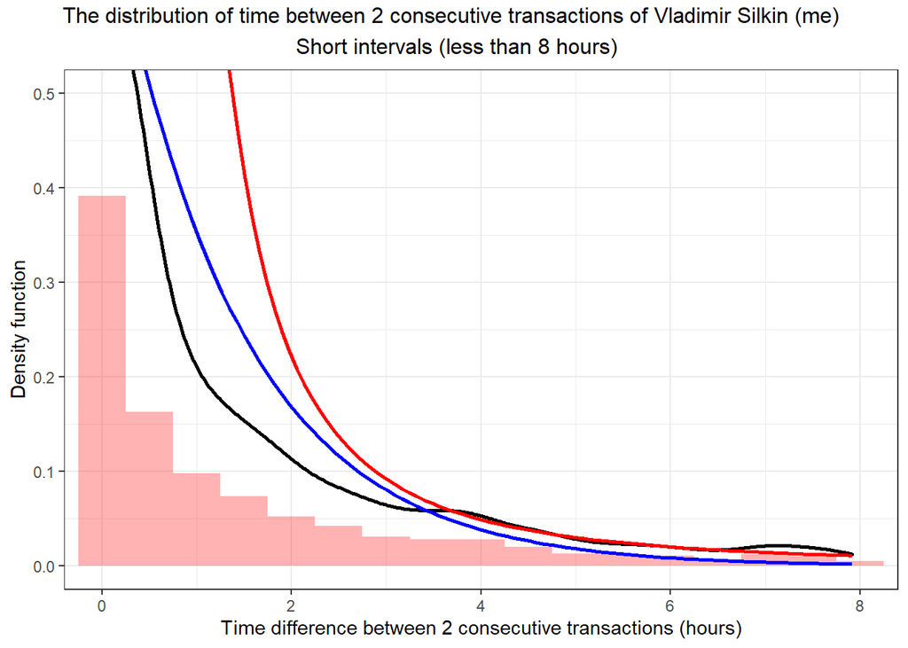

### Выводы

Я буду рад, если моя статья оказалось кому-то полезной. Если копать глубже, дальше и больше, то хотелось бы найти ответы на следующие вопросы:

1. Есть ли какой-то физический смысл у медианы распределения интервалов? Сейчас мне кажется, что она характеризует способность человека принимать спонтанные решения о покупках, поэтому я ожидаю, что она будет увеличиваться с возрастом.
2. Можно ли что-то сказать о теоретическом распределении наших данных и можно ли только на их основе сделать вывод о принадлежности их фактического распределения какому-то из основных видов?